# Intertidal

Chris Matechik

11/10/2021

First, lets download the packages we need. I like to put a conditional ‘if’ so I don’t waste time re-downloading them if I already have them.

Import the data,then take a quick glimpse to make sure everything is in order.

```r
IntData<-read.csv(file="ABSI Intertidal Data 1 Aug 2021.csv")
glimpse(IntData)
```

```
## Rows: 1,332
## Columns: 20
## $ date                         <chr> "3/23/2021", "3/23/2021", "3/23/2021", "3…
## $ month                        <int> 3, 3, 3, 3, 3, 3, 3, 3, 3, 3, 3, 3, 3, 3,…
## $ year                         <int> 2021, 2021, 2021, 2021, 2021, 2021, 2021,…
## $ Samp_ID                      <chr> "EC2_S3_3-23-21", "EC3_S1_3-23-21", "EC4_…
## $ region                       <chr> "EC", "EC", "EC", "EC", "EC", "EC", "EC",…
## $ site                         <int> 2, 3, 4, 1, 1, 1, 1, 2, 2, 2, 3, 4, 5, 5,…
## $ height                       <int> 3, 3, 3, 4, 4, 4, 4, 4, 4, 4, 4, 4, 4, 4,…
## $ length                       <int> 2, 3, 2, 4, 3, 3, 3, 2, 3, 3, 2, 3, 3, 3,…
## $ width                        <int> 2, 3, 1, 1, 2, 2, 2, 2, 1, 1, 2, 1, 2, 2,…
## $ shell_wet                    <dbl> 8.84, 10.43, 2.79, 7.32, 15.89, 10.30, 14…
## $ shell_dry                    <dbl> 8.37, 9.64, 2.31, 6.05, 14.56, 9.53, 13.2…
## $ tissue_wet                   <dbl> 1.98, 2.77, 0.72, 1.47, 2.72, 3.16, 4.10,…
## $ tissue_dry                   <dbl> 0.44, 0.77, NA, 0.35, 0.61, 0.69, 0.90, 0…
## $ total_weight_wet             <dbl> 10.82, 13.20, 3.51, 8.79, 18.61, 13.46, 1…
## $ Dry.Flesh.to.Dry.Shell..FWC. <dbl> 0.052568698, 0.079875519, NA, 0.057851240…
## $ cond_index                   <dbl> 5.25687, 7.98755, NA, 5.78512, 4.18956, 7…
## $ meat_yield                   <dbl> 18.299445, 20.984848, 20.512821, 16.72354…
## $ height_to_weight             <dbl> 0.2772643, 0.2272727, 0.8547009, 0.455062…
## $ height_to_width              <dbl> 1.5000000, 1.0000000, 3.0000000, 4.000000…
## $ Notes                        <chr> "", "", "", "", "", "", "", "", "", "", "…
```

```r
head(IntData)
```

```
##        date month year        Samp_ID region site height length width shell_wet
## 1 3/23/2021     3 2021 EC2_S3_3-23-21     EC    2      3      2     2      8.84
## 2 3/23/2021     3 2021 EC3_S1_3-23-21     EC    3      3      3     3     10.43
## 3 3/23/2021     3 2021 EC4_S4_3-23-21     EC    4      3      2     1      2.79
## 4 3/23/2021     3 2021 EC1_S1_3-23-21     EC    1      4      4     1      7.32
## 5 3/23/2021     3 2021 EC1_S2_3-23-21     EC    1      4      3     2     15.89
## 6 3/23/2021     3 2021 EC1_S3_3-23-21     EC    1      4      3     2     10.30
##   shell_dry tissue_wet tissue_dry total_weight_wet Dry.Flesh.to.Dry.Shell..FWC.
## 1      8.37       1.98       0.44            10.82                   0.05256870
## 2      9.64       2.77       0.77            13.20                   0.07987552
## 3      2.31       0.72         NA             3.51                           NA
## 4      6.05       1.47       0.35             8.79                   0.05785124
## 5     14.56       2.72       0.61            18.61                   0.04189560
## 6      9.53       3.16       0.69            13.46                   0.07240294
##   cond_index meat_yield height_to_weight height_to_width Notes
## 1    5.25687   18.29945        0.2772643             1.5
## 2    7.98755   20.98485        0.2272727             1.0
## 3         NA   20.51282        0.8547009             3.0
## 4    5.78512   16.72355        0.4550626             4.0
## 5    4.18956   14.61580        0.2149382             2.0
## 6    7.24029   23.47697        0.2971768             2.0
```

Create a data set, htvswt (height vs weight) for the analyses that drops any rows with ‘NA’ for height or weight.

```r
htvswt<-IntData %>%
  filter(height>= 25) %>%
  drop_na(total_weight_wet) %>%
  drop_na(height)
```

Make a quick scatterplot to visualize the data. We will call this scatterplot plothtvswt so we can call it later and overlay model results on it.

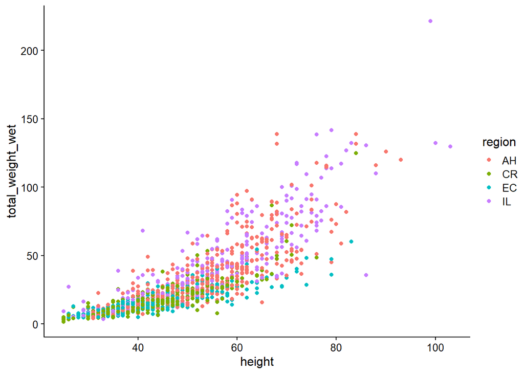

```r
plothtvswt<-
  ggplot(htvswt,aes(x=height,y=total_weight_wet,colour=region))+
  geom_point(aes(x=height,y=total_weight_wet))+
  theme_cowplot(12)
plothtvswt
```

Now make a simple model. This model does not have interactions, so the slopes for all regions will be the same. This will probably not be a good fit, but I’m trying to illustrate how adding interactions allows the other slopes to vary from the reference.

```r
model1 <- glm(total_weight_wet ~ height + region,data=htvswt)
summary(model1)
```

```
##
## Call:
## glm(formula = total_weight_wet ~ height + region, data = htvswt)
##
## Deviance Residuals:
##     Min       1Q   Median       3Q      Max
## -55.509   -8.273   -1.116    6.181  111.176
##
## Coefficients:
##              Estimate Std. Error t value Pr(>|t|)
## (Intercept) -40.57328    1.88523 -21.522  < 2e-16 ***
## height        1.45650    0.03202  45.490  < 2e-16 ***
## regionCR     -4.69285    1.11935  -4.192 2.96e-05 ***
## regionEC     -7.22838    1.16454  -6.207 7.39e-10 ***
## regionIL      6.60369    1.07301   6.154 1.02e-09 ***
## ---
## Signif. codes:  0 '***' 0.001 '**' 0.01 '*' 0.05 '.' 0.1 ' ' 1
##
## (Dispersion parameter for gaussian family taken to be 188.4062)
##
##     Null deviance: 802977  on 1220  degrees of freedom
## Residual deviance: 229102  on 1216  degrees of freedom
## AIC: 9868.4
##
## Number of Fisher Scoring iterations: 2
```

This model is probably flawed for a few reasons. First, we have reason to suspect that the slopes should not be the same. Second, we probably need a different distribution. Third, we need to deal with temporal autocorrelation. We can keep adding terms to correct these. First, lets graph this model so we can visually see why it is not a good fit.

```r
#get model predictions
resultsmodel1<-predict.glm(model1,se.fit= TRUE)
#Update resultsmodel1 to include oritginal model data and predictions.
resultsmodel1<-cbind(htvswt,resultsmodel1)
#Take a quick look to verify that fit and se were added to resultsmodel1
head(resultsmodel1)
```

```
##         date month year         Samp_ID region site height length width
## 1 12/15/2020    12 2020 IL4_Q2_12-15-20     IL    4     41      8    21
## 2   6/8/2021     6 2021   CR4_S1_6-8-21     CR    4     25     19    10
## 3   3/2/2021     3 2021   CR1_S3_3-2-21     CR    1     25     24     8
## 4  1/20/2021     1 2021  CR1_S5_1-20-21     CR    1     25     19     7
## 5  8/12/2020     8 2020  CR1_S2_8-12-20     CR    1     25     19     5
## 6  5/20/2020     5 2020  IL5_S4_5-20-20     IL    5     25     25     7
##   shell_wet shell_dry tissue_wet tissue_dry total_weight_wet
## 1     64.37     57.99       3.84       0.57            68.21
## 2      3.34      3.05       0.58       0.15             3.92
## 3      4.30      3.83       0.73       0.14             5.03
## 4      2.33      1.90       0.64       0.08             2.97
## 5      1.25      1.06       0.19       0.01             1.44
## 6      8.48      7.71       0.59       0.17             9.07
##   Dry.Flesh.to.Dry.Shell..FWC. cond_index meat_yield height_to_weight
```

[output cut: 20 more lines]

Now that we have predictions, we can overlay them on the plot we made earlier.

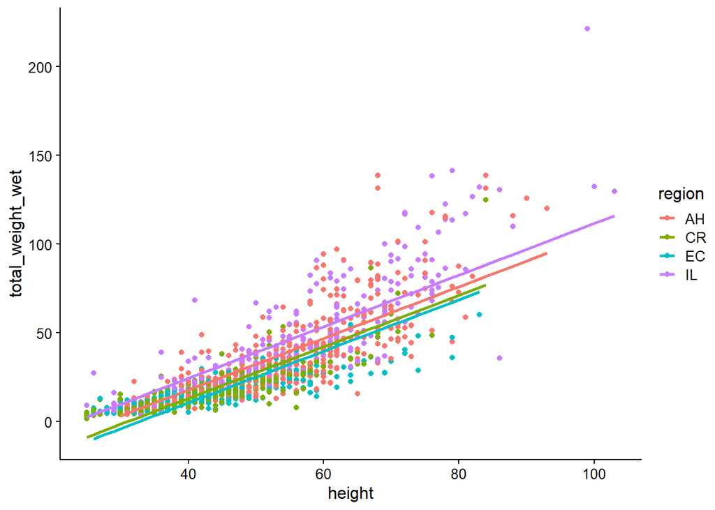

```r
plotmodel1 <-
  #call the plot we already made
  plothtvswt+
  #add a line for the model predictions.
  geom_line(data=resultsmodel1,aes(y=fit),size=1)+
  theme_cowplot(12)
plotmodel1
```

Gross. That fit is not good. We don’t need to run any residual tests. It is very obviously a bad fit. One thing that would improve the fit is allowing the slopes to be different. Interactions can accomplish this.

So, we’ll create a second model and allow for interactions. Note that in the glm formula the asterisk (*) signifies interactions. If you just include the asterisk, R will automatically include the interactions for every possible combination of main effects, but you could specify these manually.

For example, the formulas below are equivalent: model2 <- glm(total_weight_wet ~ height * region,data=htvswt) model2 <- glm(total_weight_wet ~ height + region + height * region,data=htvswt)

You could even specify them by each value in the term (e.g. AH, CR, EC, IL), but I digress. Let’s get back to the model. We will create it just like before, but I’ll add the interaction term.

```r
model2 <- glm(total_weight_wet ~ height * region,data=htvswt)
summary(model2)
```

```
##
## Call:
## glm(formula = total_weight_wet ~ height * region, data = htvswt)
##
## Deviance Residuals:
##     Min       1Q   Median       3Q      Max
## -66.722   -5.747   -0.670    4.083   95.384
##
## Coefficients:
##                  Estimate Std. Error t value Pr(>|t|)
## (Intercept)     -54.32355    3.04329 -17.850  < 2e-16 ***
## height            1.70857    0.05448  31.360  < 2e-16 ***
## regionCR         26.51792    4.37299   6.064 1.77e-09 ***
## regionEC         39.18350    4.43747   8.830  < 2e-16 ***
## regionIL          1.27227    4.12756   0.308    0.758
## height:regionCR  -0.65184    0.08864  -7.354 3.53e-13 ***
## height:regionEC  -0.99623    0.08976 -11.099  < 2e-16 ***
## height:regionIL   0.10019    0.07369   1.360    0.174
## ---
## Signif. codes:  0 '***' 0.001 '**' 0.01 '*' 0.05 '.' 0.1 ' ' 1
##
## (Dispersion parameter for gaussian family taken to be 160.6224)
##
##     Null deviance: 802977  on 1220  degrees of freedom
## Residual deviance: 194835  on 1213  degrees of freedom
## AIC: 9676.5
##
## Number of Fisher Scoring iterations: 2
```

The interaction rows tell you how the slopes of each area region differ from that of the reference group.

Let’s graph it using the same process as before.

```r
resultsmodel2<-predict.glm(model2,se.fit= TRUE)
resultsmodel2<-cbind(htvswt,resultsmodel2)
head(resultsmodel2)
```

```
##         date month year         Samp_ID region site height length width
## 1 12/15/2020    12 2020 IL4_Q2_12-15-20     IL    4     41      8    21
## 2   6/8/2021     6 2021   CR4_S1_6-8-21     CR    4     25     19    10
## 3   3/2/2021     3 2021   CR1_S3_3-2-21     CR    1     25     24     8
## 4  1/20/2021     1 2021  CR1_S5_1-20-21     CR    1     25     19     7
## 5  8/12/2020     8 2020  CR1_S2_8-12-20     CR    1     25     19     5
## 6  5/20/2020     5 2020  IL5_S4_5-20-20     IL    5     25     25     7
##   shell_wet shell_dry tissue_wet tissue_dry total_weight_wet
## 1     64.37     57.99       3.84       0.57            68.21
## 2      3.34      3.05       0.58       0.15             3.92
## 3      4.30      3.83       0.73       0.14             5.03
## 4      2.33      1.90       0.64       0.08             2.97
## 5      1.25      1.06       0.19       0.01             1.44
## 6      8.48      7.71       0.59       0.17             9.07
##   Dry.Flesh.to.Dry.Shell..FWC. cond_index meat_yield height_to_weight
```

[output cut: 20 more lines]

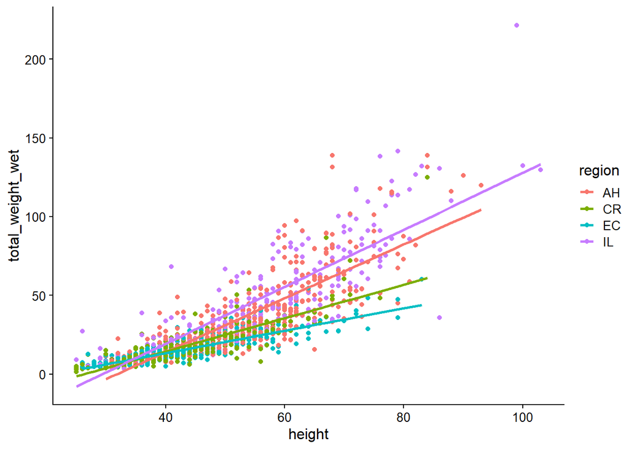

```r
plotmodel2 <-
  plothtvswt+
  geom_line(data=resultsmodel2,aes(y=fit),size=1)+
  theme_cowplot(12)
plotmodel2
```

You can see, it’s a better fit, but still not great.

We might need a log transformation.Let’s make some plots to visually see if transformation will help.

First, we’ll try taking the log of Y

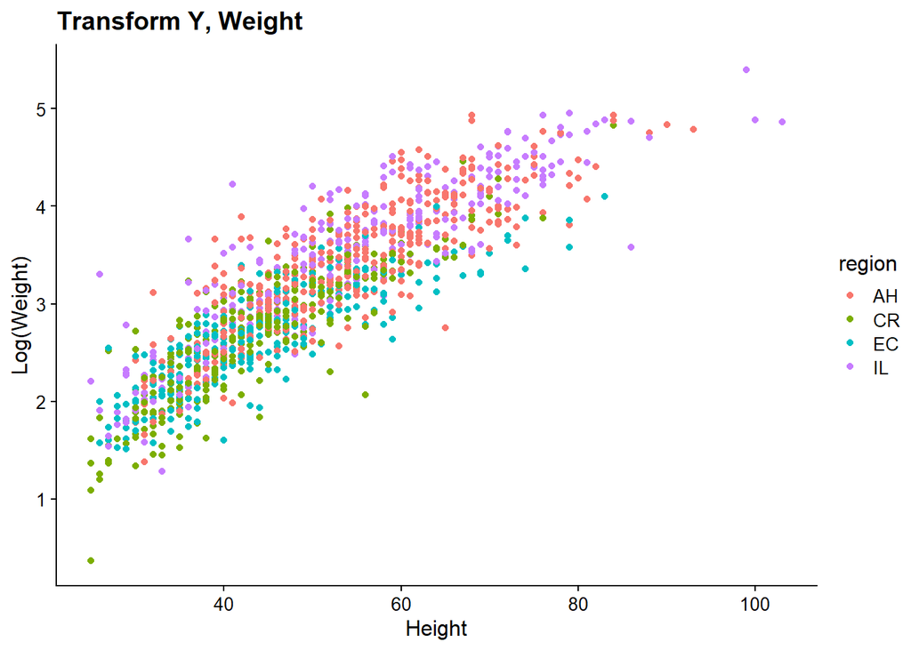

```r
plotTransy<-
  ggplot(htvswt,aes(x=(height),y=log(total_weight_wet),colour=region))+
  geom_point(aes(x=(height),y=log(total_weight_wet)))+
  labs(x='Height',y='Log(Weight)')+
  ggtitle("Transform Y, Weight")+
  theme_cowplot(12)
plotTransy
```

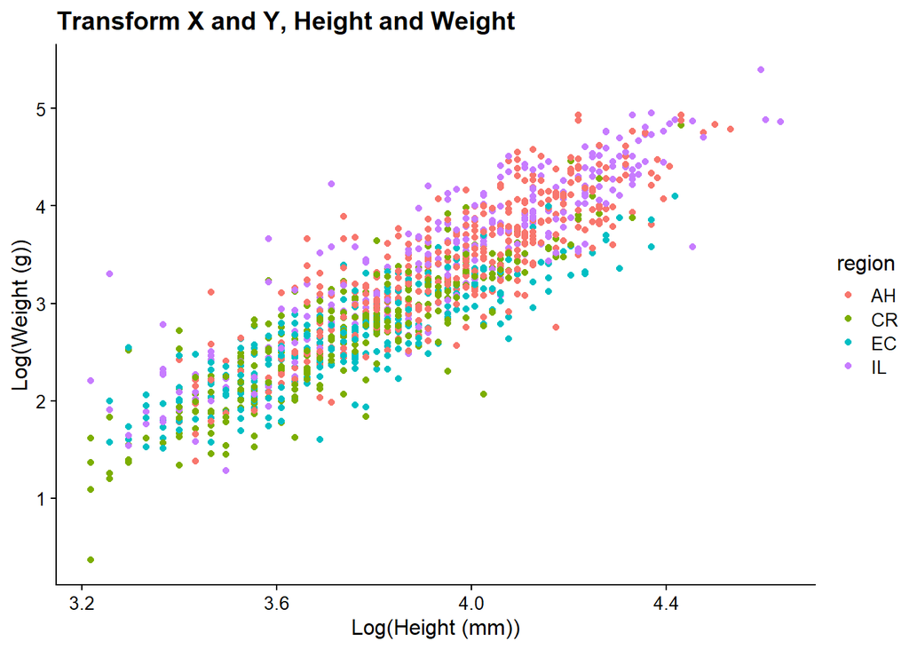

```r
plotTransXY<-
  ggplot(htvswt,aes(x=log(height),y=log(total_weight_wet),colour=region))+
  geom_point(aes(x=log(height),y=log(total_weight_wet)))+
  labs(x='Log(Height (mm))',y='Log(Weight (g))')+
  ggtitle("Transform X and Y, Height and Weight")+
  theme_cowplot(12)
plotTransXY
```

That looks much more linear! We will model these data.

```r
model3 <- glm(log(total_weight_wet) ~ log(height) * region,data=htvswt)
summary(model3)
```

```
##
## Call:
## glm(formula = log(total_weight_wet) ~ log(height) * region, data = htvswt)
##
## Deviance Residuals:
##      Min        1Q    Median        3Q       Max
## -1.31070  -0.20840  -0.01274   0.20956   1.45008
##
## Coefficients:
##                      Estimate Std. Error t value Pr(>|t|)
## (Intercept)          -6.61741    0.30408 -21.762  < 2e-16 ***
## log(height)           2.53298    0.07639  33.158  < 2e-16 ***
## regionCR              0.08308    0.43089   0.193    0.847
## regionEC              2.05460    0.44411   4.626 4.12e-06 ***
## regionIL              0.60239    0.40528   1.486    0.137
## log(height):regionCR -0.07093    0.11154  -0.636    0.525
## log(height):regionEC -0.61492    0.11510  -5.342 1.09e-07 ***
## log(height):regionIL -0.11735    0.10202  -1.150    0.250
## ---
## Signif. codes:  0 '***' 0.001 '**' 0.01 '*' 0.05 '.' 0.1 ' ' 1
##
## (Dispersion parameter for gaussian family taken to be 0.1116115)
##
##     Null deviance: 762.75  on 1220  degrees of freedom
## Residual deviance: 135.38  on 1213  degrees of freedom
## AIC: 797.7
##
## Number of Fisher Scoring iterations: 2
```

Now we will plot it. Again, we will predict the values from the model and then bind them to the dataset.

```r
resultsmodel3<-predict.glm(model3,se.fit= TRUE)
resultsmodel3<-cbind(htvswt,resultsmodel3)
```

Then we will plot it.

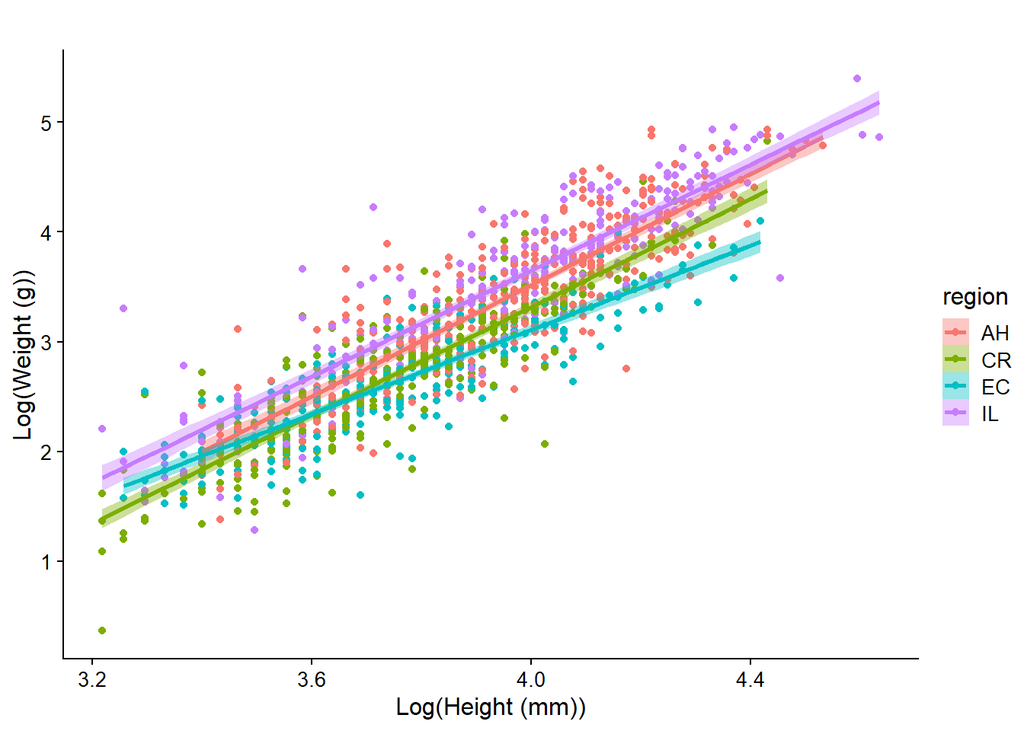

```r
plotmodel3 <-
  plotTransXY+
  geom_line(data=resultsmodel3,aes(y=fit),size=1)+
  geom_smooth(method=glm,fomrula=log(total_weight_wet) ~ log(height) * region,aes(fill=region))+
  #remove the title since we are borrowing from plotTransXY
  ggtitle("")+
  theme_cowplot(12)
plotmodel3
```

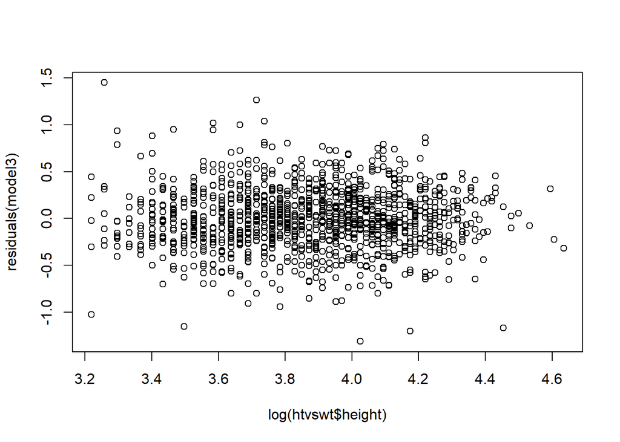

```r
plot(residuals(model3)~log(htvswt$height))
```

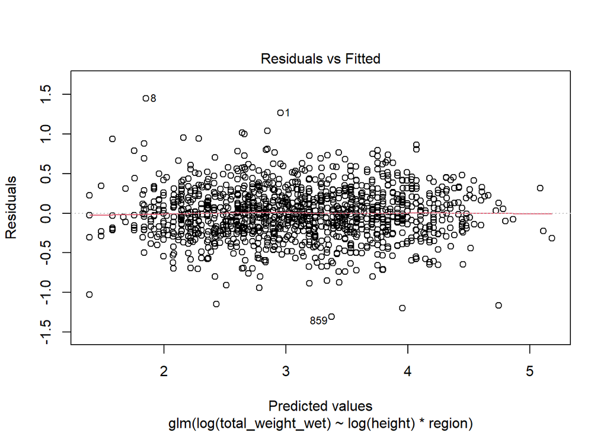

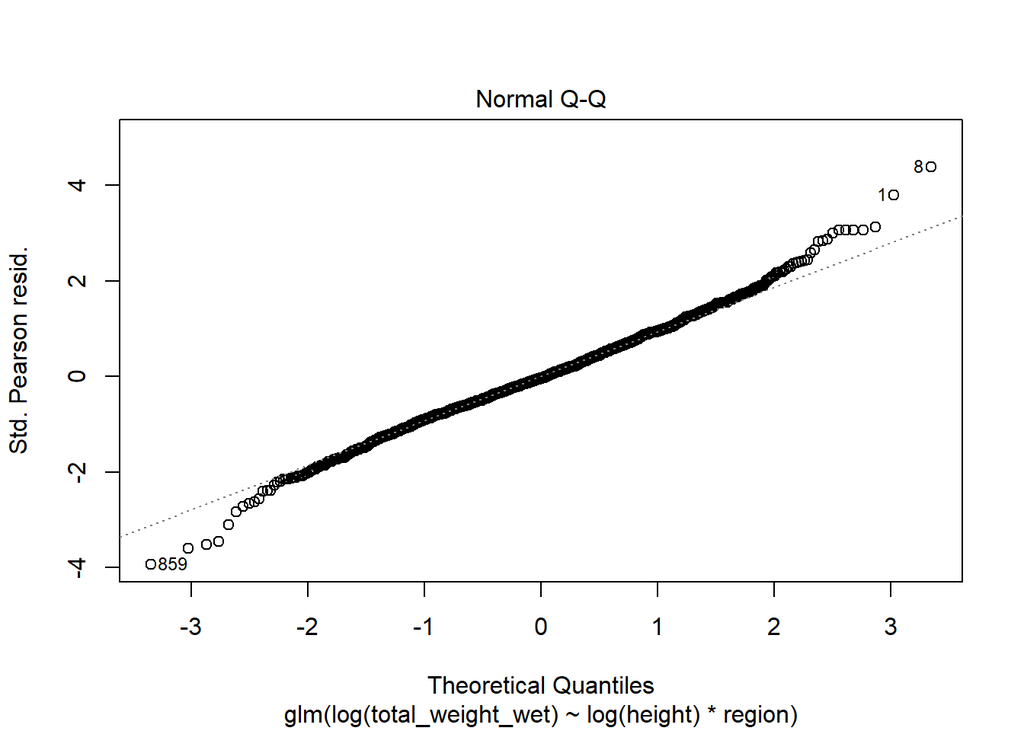

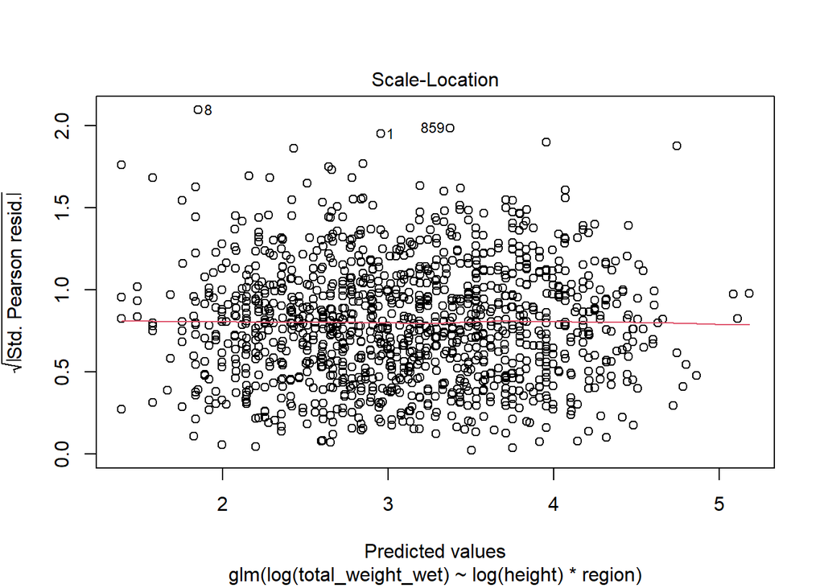

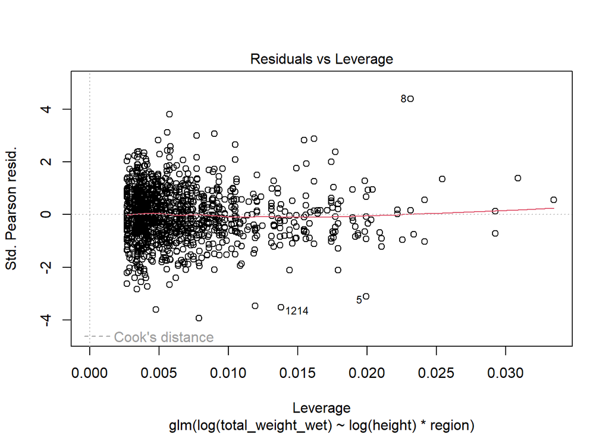

```r
plot(model3)
```

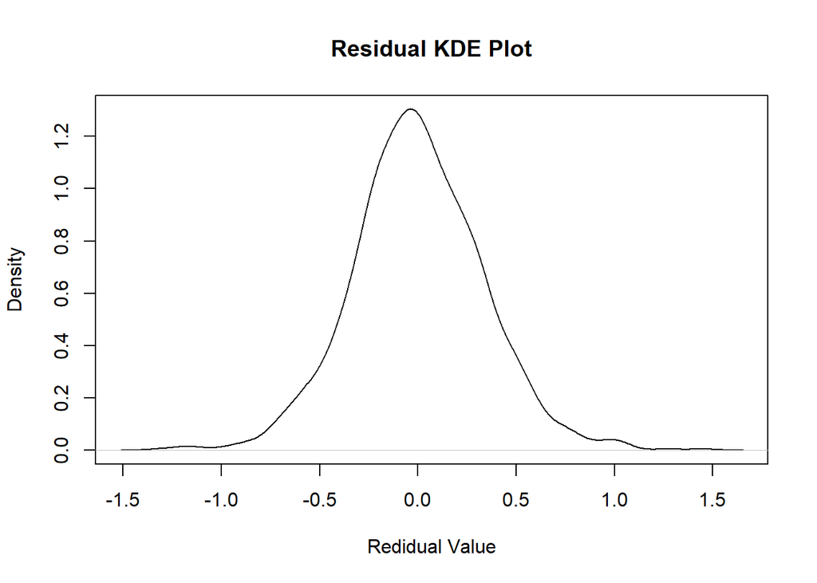

```r
KDE<-(density(model3[['residuals']]))
plot(KDE,main='Residual KDE Plot',xlab='Redidual Value')
```

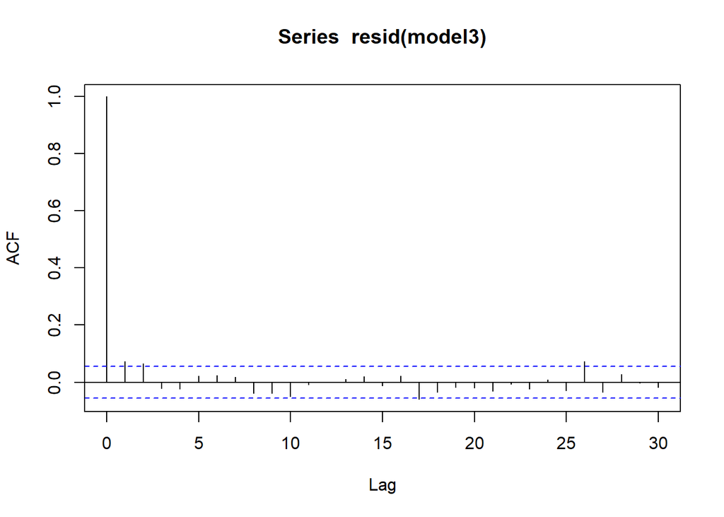

```r
acf(resid(model3))
```

Here is a quick refresher on back transforming log models. https://cscu.cornell.edu/wp-content/uploads/83_logv.pdf

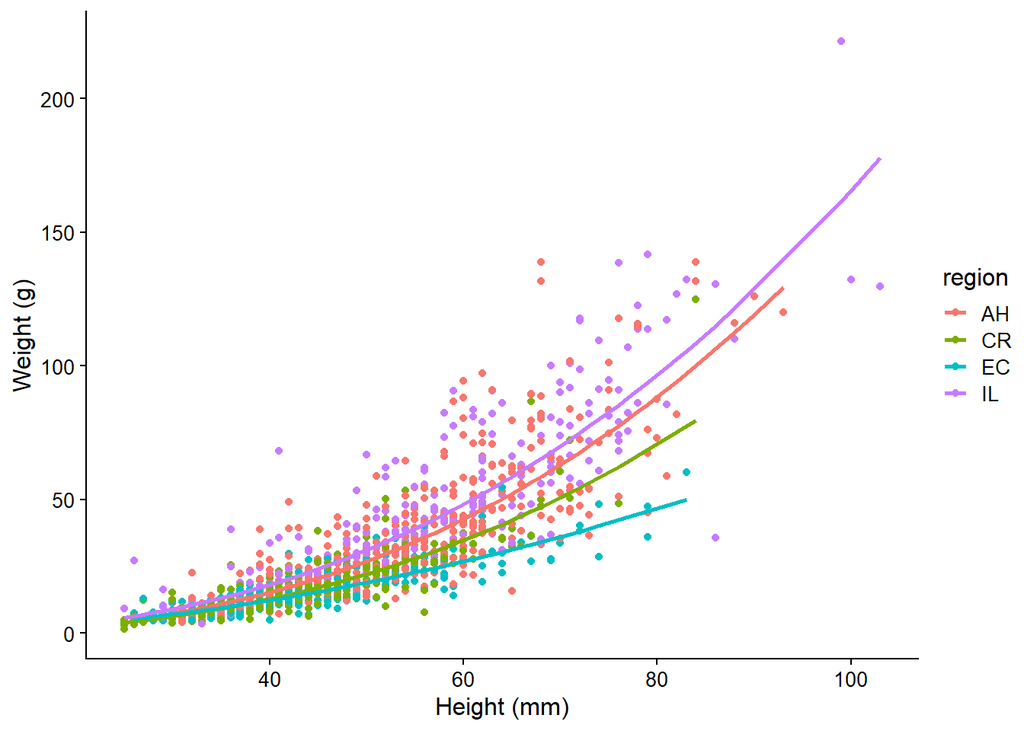

```r
plotmodel3trans <-
  plothtvswt+
  geom_line(data=resultsmodel3,aes(y=exp(fit)),size=1)+
  labs(x='Height (mm)',y='Weight (g)')+
  theme_cowplot(12)
plotmodel3trans
```